# Passenger Trip Delays in the U.S. Domestic Airline in 2008

## by Benoît Courty

## Investigation Overview

I'd like to better understand what cause flight delay.

## Dataset Overview

As stated on http://stat-computing.org/dataexpo/2009/ : The data consists of flight arrival and departure details for all commercial flights within the USA, from October 1987 to April 2008. This is a large dataset: there are nearly 120 million records in total.

The data come from the US Bureau of Transportation Statistics.

I choose to focus only on the most recent year : 2008.

The dataset contain one line per flight in the US for 2008. With 29 informations about the fligth : origin, destination, date, reason of delay, take off time... Mainly numerical. Some of them are continuous (delay) and others categorical (month).

It's only the internal US flights (domestic), not the international flight arriving/living the US.

It's already a huge file with seven millions of lines just for 2008 year.

## Arrival status

Let's have a look to the status of arrival.

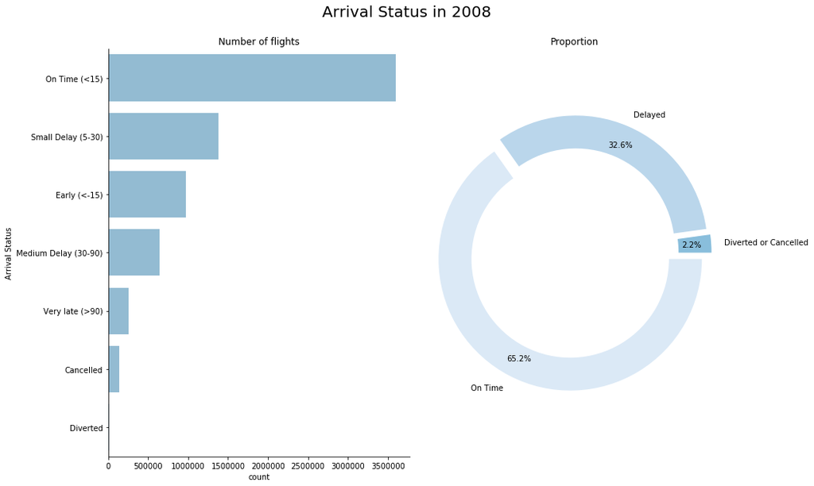

```python
# Select the color for our plot
base_color = sns.color_palette("Blues")[2]

# Set the figure
f,ax=plt.subplots(1,2,figsize=figsize);

# Plot the barplot
sns.countplot(y='ArrStatus',order = df['ArrStatus'].value_counts().index, data=df,ax=ax[0],
             color = base_color, orient='h');
# Remove line around plot
sns.despine(ax=ax[0])

ax[0].set_title('Number of flights');
ax[0].set_ylabel('Arrival Status');

# Thanks to https://medium.com/@kvnamipara/a-better-visualisation-of-pie-charts-by-matplotlib-935b7667d77f
# We loop over categorical to explode the pie
explode = []
for i in range(len(df['ArrStatus_light'].value_counts())):
    explode.append(0.05)

# Plot the Pie
df['ArrStatus_light'].value_counts().plot.pie(autopct='%1.1f%%',ax=ax[1],
                                       wedgeprops = {'width' : 0.25},
                                       startangle = 0,counterclock = False,
                                       colors = sns.color_palette("Blues"),
                                       pctdistance=0.85, explode = explode);
ax[1].set_title('Proportion');
ax[1].set_ylabel('');
ax[1].axis('equal') # Equal aspect ratio ensures that pie is drawn as a circle
plt.suptitle("Arrival Status in 2008", fontsize = 20, y = 1.05);
plt.tight_layout()
```

## Reason of delay

We must be careful about these data as we have many missing values for them. I don't know if it means that it was 0 or unregistered values.

Late Aircraft delay is the one causing the more delay, on average. But NAS Delay is the most frequent delay.

It's a real problem, we saw that delay are causing more delay. Maybe company need to be incentived to reduce delay by flying faster, even if it cost, to reduce them ?

There is almos no Security Delay. That's something I feel strange about it. I thing there is missing data about it.

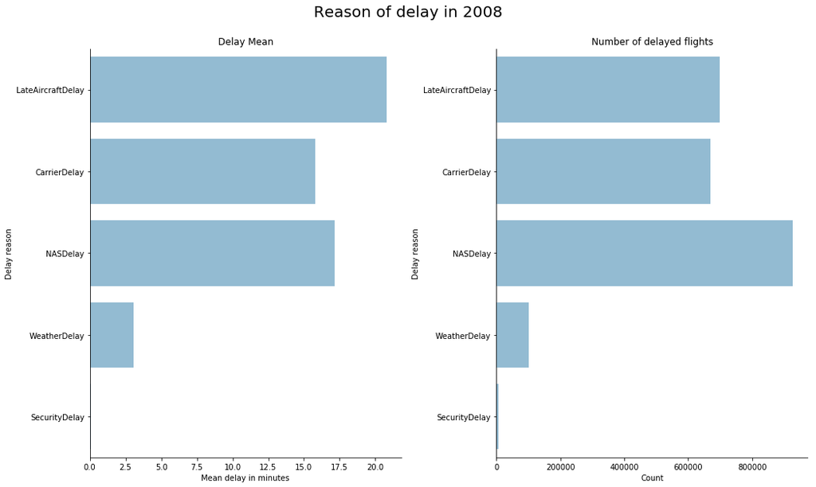

```python
reasons = ['LateAircraftDelay', 'CarrierDelay', 'NASDelay', 'WeatherDelay', 'SecurityDelay' ]
reason_label = ['Late aircraft','Carrier','National Air System','Weather', 'Security']
name = []
sum_delay = []
num_delay = []
for reason in reasons:
    name.append(reason)
    sum_delay.append(df_late[reason].mean())
    num_delay.append(
        len( df_late.query(reason + " > 0") )
    )

fig,ax=plt.subplots(1,2,figsize=figsize);
axp = sns.barplot(y=name, x=sum_delay, ax=ax[0], color=sns.color_palette("Blues")[2], orient='h');
sns.despine(ax=axp);
#ax[0].set_yticklabels(reason_label, rotation=40, ha="right")
ax[0].set_title('Delay Mean');
ax[0].set_ylabel('Delay reason');
ax[0].set_xlabel('Mean delay in minutes')

axp = sns.barplot(y=name, x=num_delay, ax=ax[1], color=sns.color_palette("Blues")[2], orient='h');
sns.despine(ax=axp);
#ax[1].set_yticklabels(reason_label, rotation=40, ha="right")
ax[1].set_title('Number of delayed flights');
ax[1].set_ylabel('Delay reason');
ax[1].set_xlabel('Count')
plt.suptitle("Reason of delay in 2008", fontsize = 20, y = 1.05);
plt.tight_layout()
```

## Reason of cancellation

Why a plane is cancelled ?

I was expecting more cancellation for security reason. But it almost never append.

Weather and Carrier are equaly responsible of delay.

I was surprised by the amount of NAS cancellation. According to http://www.flightbucks.com/blog/9-biggest-causes-of-flight-delays-or-cancellations This might include non-severe weather events, heavy air traffic, air traffic control delays, and airport operations.

20% is huge but we have to remember that it's 20% of cancellation, wich occure only 2% of flights.

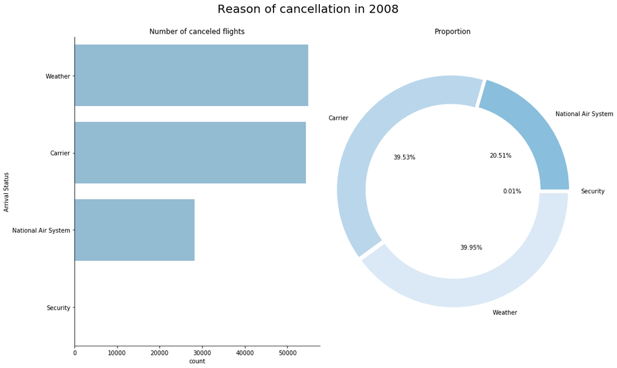

```python
base_color = sns.color_palette("Blues")[2]

f,ax=plt.subplots(1,2,figsize=figsize);
#with sns.axes_style("whitegrid"):
axp = sns.countplot(y='CancellationReason', order = df['CancellationReason'].value_counts().index,
                    data=df, ax=ax[0], color = base_color, orient='h');
sns.despine(ax=axp);
axp.set_title('Number of canceled flights');
axp.set_ylabel('Arrival Status');
#axp.set_yticklabels(ax[0].get_yticklabels(), rotation=40, ha="right");

# Thanks to https://medium.com/@kvnamipara/a-better-visualisation-of-pie-charts-by-matplotlib-935b7667d77f
#explosion
explode = []
for i in range(len(df['CancellationReason'].value_counts())):
    explode.append(0.02)

df['CancellationReason'].value_counts().plot.pie(autopct='%1.2f%%',ax=ax[1],
                                       wedgeprops = {'width' : 0.25},
                                       startangle = 0, counterclock = False,
                                       colors = sns.color_palette("Blues"),
                                       pctdistance=0.50, explode = explode);

ax[1].set_title('Proportion');
ax[1].set_ylabel('');
#ax[1].set_xticklabels(ax[1].get_xticklabels(), rotation=40, ha="right");
# Equal aspect ratio ensures that pie is drawn as a circle
ax[1].axis('equal')
plt.suptitle("Reason of cancellation in 2008", fontsize = 20, y = 1.05);
plt.tight_layout()
```

## Delay by major cities

If think it will be interresting to see if there is difference between airports regarding delay.

Newark is the departure city where, in average, you have to expect to be late.

But the distribution is large : you have more than 25% chance to arrive early.

If it's your destination, you also have to expect to be late, in more than 50% of the flights, in average.

What is interesting is some of top departure with hight mean delay are not in the Top 10 for destination, like Milwaukee.

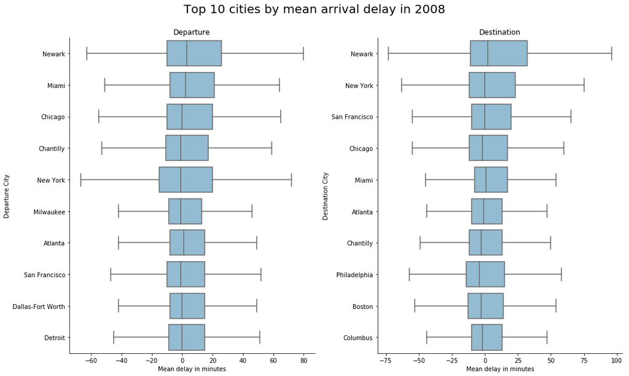

```python
## 1 Filter the city with most flights
# Get the 50 cities with with most flights
df_most_flights = df.groupby(['OriginCity'])['Month'].count().sort_values(ascending = False).reset_index();
df_most_flights = df_most_flights[:50]
# Filter the dataset on them
df_late_ori_city = df[df['OriginCity'].isin(df_most_flights['OriginCity'])]
df_late_dest_city = df[df['DestCity'].isin(df_most_flights['OriginCity'])]

# 2 Compute the order by delay mean
delay_origin_city_order = df_late_ori_city.groupby(['OriginCity'])['ArrDelay'].mean().sort_values(ascending = False).index[:10]
delay_dest_city_order = df_late_dest_city.groupby(['DestCity'])['ArrDelay'].mean().sort_values(ascending = False).index[:10]

# Initiate a figure
plt.figure(figsize = figsize)
plt.subplots_adjust(wspace = 0.85) # adjust spacing between subplots, in order to show long city names nicely
# Draw the first boxplot
plt.subplot(1, 2, 1)
ax1 = sns.boxplot(x = df_late_ori_city['ArrDelay'], y = df_late_ori_city['OriginCity'], order = delay_origin_city_order,
            color = sns.color_palette("Blues")[2], showfliers=False);
sns.despine(ax=ax1);
plt.xlabel('Mean delay in minutes')
plt.ylabel('Departure City')
plt.title('Departure');

plt.subplot(1, 2, 2)
ax2 = sns.boxplot(x = df_late_dest_city['ArrDelay'], y = df_late_dest_city['DestCity'], order = delay_dest_city_order,
            color = sns.color_palette("Blues")[2], showfliers=False);
sns.despine(ax=ax2);
plt.xlabel('Mean delay in minutes')
plt.ylabel('Destination City')
plt.title('Destination');
plt.suptitle("Top 10 cities by mean arrival delay in 2008", fontsize = 20, y = 1.05);
plt.tight_layout()
```

## Average delay by Carrier

Let's look at how delay evolve between carrier.

While Aloha Airline are landind early on average !

If I look only at top 3 carriers, who operate more than 500 000 flights per year, we have :

- American Airline are 13 minutes late on average
- SkyWest 6 min
- SouthWest 5 min

So, based on that, we could say that you have to avoid American Airline to be on time.

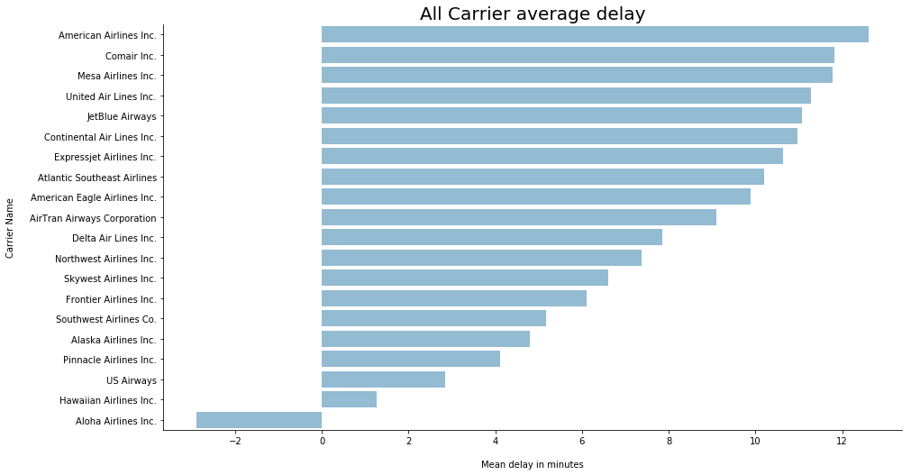

```python
# Get the Carrier with more than 1000 flights in the main dataset
df_most_flights = df.groupby(['CarrierName'])['Month'].count().sort_values(ascending = False).reset_index();
df_most_flights = df_most_flights.query("Month > 500")
# Filter the df dataset for them
df_late_plane = df[df['CarrierName'].isin(df_most_flights['CarrierName'])]
# Compute the delay mean for them
df_late_plane = df_late_plane.groupby(['CarrierName'])['ArrDelay'].mean().sort_values(ascending = False).reset_index();
# Plot the top 15
plot_categorical_variable(df_late_plane, 'ArrDelay', 'CarrierName', 'Mean delay in minutes','Carrier Name',  title='All Carrier average delay')
```

## Delay by day of week and hour of day

Let's have a look at three variable at a time : delay, hour of day, day of week.

Worst time to take a plane is friday and sunday evening, probably because of people going and returning of week-end trip.

And also realy early (3/4 am) in the morning, maybe because teams are not fully operational at that time ?

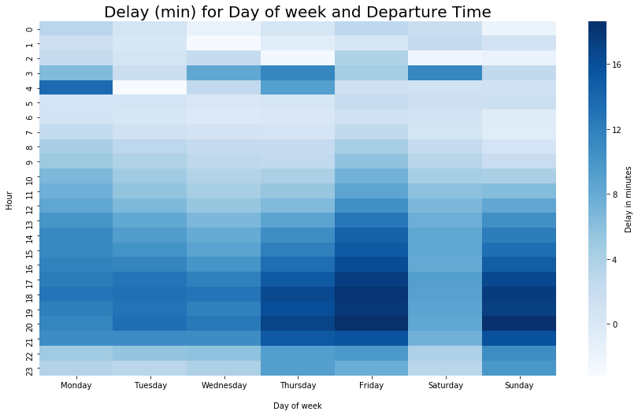

```python
plt.figure(figsize=figsize)
# Group by hour of day, day of week and compute the mean
df_group = df.groupby(['CRSDepTimeHour', 'DayOfWeek'])['ArrDelay'].mean().reset_index();
# Pivot the table to get a matrix of hour_of_day x day_of_week containing the mean
df_pivot = df_group.pivot('CRSDepTimeHour', 'DayOfWeek', 'ArrDelay');

# Plot a heatmap.
heat_map = sns.heatmap(df_pivot, cmap = 'Blues', cbar_kws={'label': 'Delay in minutes'});
day_label = ['Monday','Tuesday','Wednesday','Thursday', 'Friday', 'Saturday', 'Sunday']
heat_map.set(xticklabels=day_label)
plt.title('Delay (min) for Day of week and Departure Time', fontsize=20);
plt.xlabel('Day of week', labelpad = 16);
plt.ylabel('Hour',  labelpad = 16);
```

## Geographical delay

I'd like to show you delay by states on a USA map.

Alaska and Hawai have been removed for readability.

We see that there is less delay everywhere in fall.

We saw that Illinois and Wisconsin are more subject to delay in Winter.

It's nice to see that our delay map quite match with temperature mean temperature in USA states https://www.currentresults.com/Weather/US/average-state-temperatures-in-winter.php !

Illinois seems in the top delay state in every season.

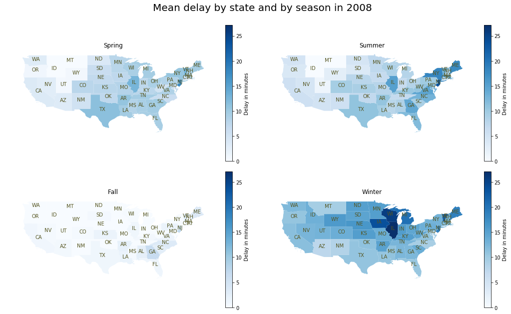

```python
#!pip install geopandas descartes

import geopandas as gpd
df_orig_season_delay_geo = df[['OriginState', 'OriginStateName', 'Season', 'ArrDelay']] # WeatherDelay > 10 and
df_orig_season_delay_geo.dropna(inplace=True)
df_orig_season_delay_geo = df_orig_season_delay_geo.groupby(['OriginStateName', 'OriginState', 'Season'])['ArrDelay'].mean().reset_index();
df_orig_season_delay_geo.head(3)

# You have to downlaod and unzip https://www2.census.gov/geo/tiger/GENZ2017/shp/cb_2017_us_state_20m.zip
# To get the map background.
shape = "./cb_2017_us_state_20m/cb_2017_us_state_20m.shp"
usa_map = gpd.read_file(shape)
df_map = usa_map.merge(df_orig_season_delay_geo, how='left', left_on='NAME', right_on='OriginStateName')

seasons = ['Spring', 'Summer', 'Fall', 'Winter']
# Zoom to US only, without Alaska and Hawai
df_non_alaska = df_map.cx[-120:-65, 20:80]

# Initiate a figure
fig = plt.figure(figsize = [14.70, 8.27])
i=0
vmax=df_non_alaska.ArrDelay.max()
for season in seasons:
    # Thanks to https://github.com/bendoesdata/make-a-map-geopandas
    # Locate the plot
    ax = plt.subplot(2, 2, i+1);
    # Set the title to the current Season
    _ = ax.set_title(season);
    # Draw the map
    ax_map = df_non_alaska.query("Season == @season").plot(column='ArrDelay', ax=ax, cmap='Blues', legend=False,
                                                     vmin=0, vmax=vmax);
    # thanks to https://stackoverflow.com/questions/38899190/geopandas-label-polygons
    # We plot the States code with or size
    _ = df_non_alaska.query("Season == @season").apply(lambda x: ax.annotate(s=x.OriginState, xy=x.geometry.centroid.coords[0],
               fontsize=10, ha='center', color='#555520'),axis=1);
    # Draw or own legend to add text on it
    legend = ax_map.collections[0]
    legend = plt.colorbar(legend, ax=ax)
    legend.set_label('Delay in minutes')
    # remove the axis
    _ = ax.axis('off');
    i+=1
plt.tight_layout()
plt.suptitle("Mean delay by state and by season in 2008", fontsize = 20, y = 1.05);
```

# Thank you

We learn many things on flights in US, many of them need to be investigate further to see if our guess are well funded.

I hope you enjoy what you see as much as I love to dig it into datas.